# peerassessment1

The code below loads the activity data and preprocesses it by removing observations with unknown steps (“NA”).

```r
activitydata <- read.csv("activity.csv")
activitydataclean <- activitydata[!is.na(activitydata$steps),]
```

The total number of steps for each day are calculated and plotted using a histogram

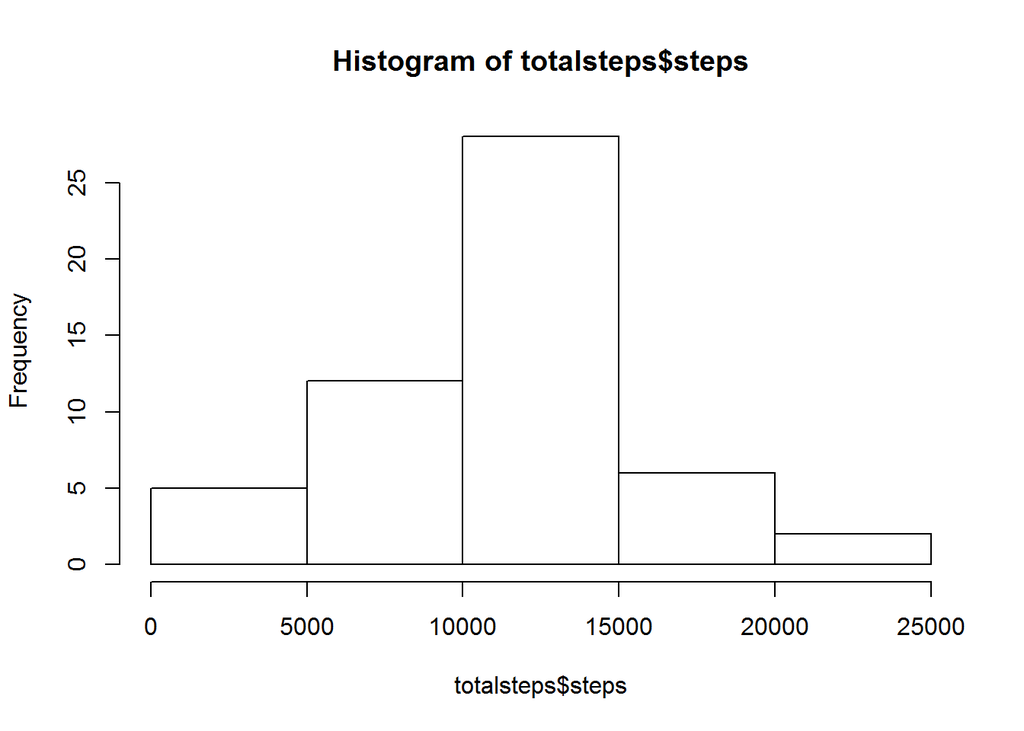

```r
totalsteps <- aggregate(steps ~ date, data=activitydataclean, FUN = function(x) c(S = sum(x)))
hist(totalsteps$steps)
```

The mean of total steps is

```r
mean(totalsteps$steps)
```

```
## [1] 10766.19
```

The median steps are

```r
median(totalsteps$steps)
```

```
## [1] 10765
```

The averate daily activity pattern looks like below

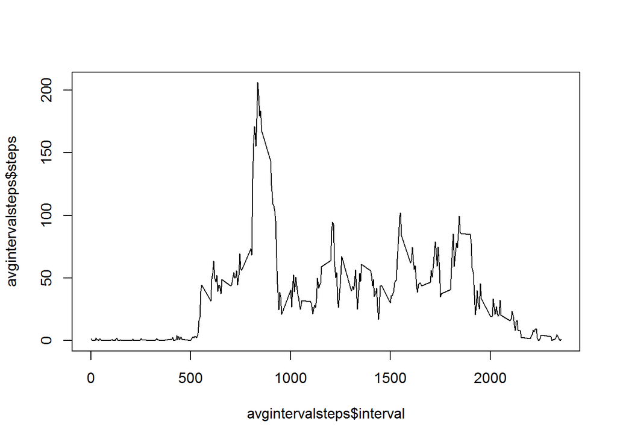

```r
avgintervalsteps <- aggregate(steps ~ interval, data=activitydataclean, FUN = function(x) c(M = mean(x)))
plot(avgintervalsteps$interval,avgintervalsteps$steps,type = "l")
```

The maximum number of average steps for a given 5 minute interval is

```r
max(avgintervalsteps$steps)
```

```
## [1] 206.1698
```

the maximum is in the 5 minute interval ending with

```r
avgintervalsteps[avgintervalsteps$steps == max(avgintervalsteps$steps), 1]
```

```
## [1] 835
```

The total number of missing values in the dataset are

```r
sum(is.na(activitydata$steps))
```

```
## [1] 2304
```

The missing data is filled with average number os steps in 5 minute interval

```r
activitydatafilled <- activitydata
activitydatafilled$steps[is.na(activitydata$steps)]=mean(activitydataclean$steps)
```

The histogram with the new data set with filled in missign values looks like below

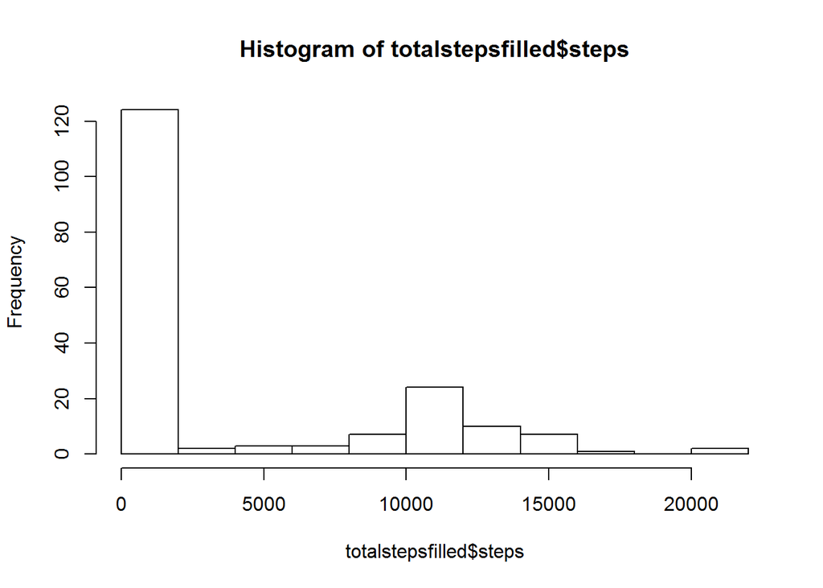

```r
totalstepsfilled <- aggregate(steps ~ date, data=activitydatafilled, FUN = function(x) c(S = sum(x), A= mean(x), M = median(x)))
hist(totalstepsfilled$steps)
```

```r
mean(totalstepsfilled$steps)
```

```
## [1] 3602.825
```

```r
median(totalstepsfilled$steps)
```

```
## [1] 37.3826
```

Now this data set is added a factor variable “weekday” and “weekend”

```r
activitydatafilledweekday <- activitydatafilled
activitydatafilledweekday$weekend  = chron::is.weekend(activitydatafilledweekday$date)
activitydatafilledweekday$weekend[activitydatafilledweekday$weekend] <- "weekend"
activitydatafilledweekday$weekend[activitydatafilledweekday$weekend == "FALSE"] <- "weekday"
```

A panel plot of steps during weekend and weekdays with the filled-in dataset looks like below

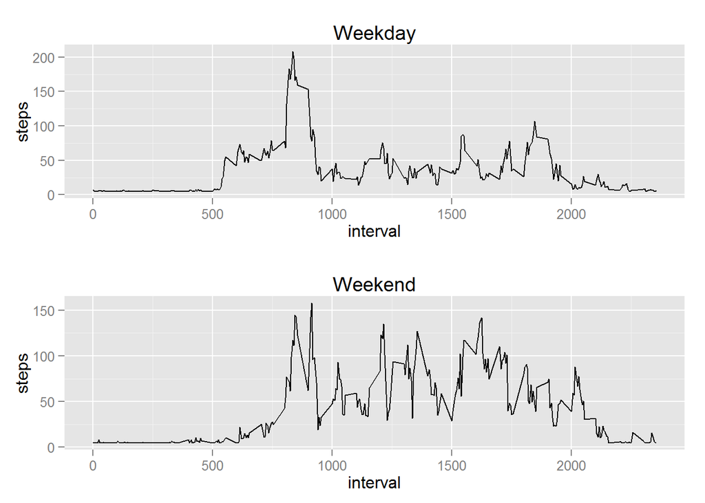

```r
activitydatafilledweekdaytrue <- activitydatafilledweekday[activitydatafilledweekday$weekend == "weekday",]
activitydatafilledweekdayfalse <- activitydatafilledweekday[activitydatafilledweekday$weekend == "weekend",]

avgintervalstepsweekday <- aggregate(steps ~ interval, data=activitydatafilledweekdaytrue, FUN = function(x) c(M = mean(x)))
avgintervalstepsweekend <- aggregate(steps ~ interval, data=activitydatafilledweekdayfalse, FUN = function(x) c(M = mean(x)))

library(ggplot2)
p1 <- ggplot(avgintervalstepsweekday,aes(x = interval, y = steps)) + geom_line() + ggtitle("Weekday")
p2 <- ggplot(avgintervalstepsweekend,aes(x = interval, y = steps)) + geom_line() + ggtitle("Weekend")

library(gridExtra)
grid.arrange(p1,p2, ncol = 1)
```